# Practica 2: ¿Qué caracteriza a los todo terreno?

Abraham Ramírez

5 de Enero de 2018

## Objetivo

En este trabajo se pretende conocer cuáles son las características fundamentales de los todo terreno, para esto, utilizaremos la técnica estadística del análisis de componentes principales.

El análisis de componentes principales, nos va a permitir tener una representación gráfica, apróximada, de una nube de puntos original que de otra forma nos sería imposible visualizar por exceso de dimensiones y explicar que variables son las que nos porporcionan más información sobre los todo terreno.

Posteriormente se realizará un análisis cluster en el que se tratará de agrupar a los todo terreno según sus características fundamentales.

## Introducción

El Análisis de Componentes Principales es una técnica estadística de síntesis de la información, o reducción de la dimensión (número de variables).Es decir, ante un banco de datos con muchas variables, el objetivo será reducirlas a un menor número perdiendo la menor cantidad de información posible.

Para nuestro análisis, contamos con una base de datos con las siguientes variables:

- Marca
- Modelo
- Precio en euros
- Número de cilindros
- Cilindrada
- Potencia
- Revoluciones por minutos
- Peso en kilos
- Número de plazas
- Consumo 90 km/h
- Consumo 120 km/h
- Consumo urbano
- Velocidad máxima
- Aceleración de 0 a 100
- Tiempo de aceleración

Esta base de datos cuenta con registros vacíos, los cuales omitiremos ya que si los modificamos o rellenamos con algún método podría afectar nuestro análisis. También se omitiran las variables categoricas Marca y Modelo, esto porque no hay manera de medir distancias entre las observaciones de estas dos variables y si las introducimos al modelo podría tener impactos negativos en el resultado final.

Procederemos a analizar la matriz de correlaciones:

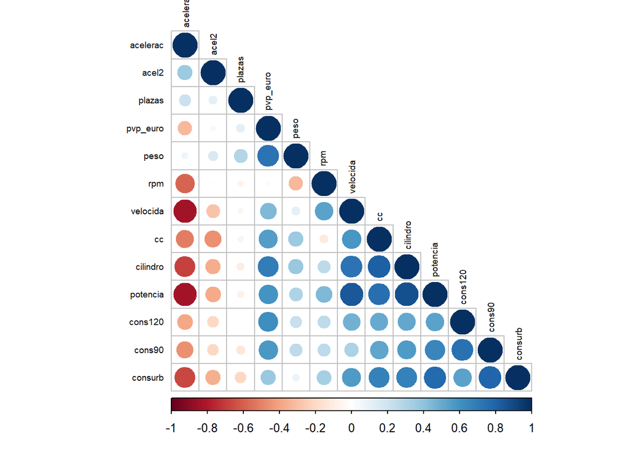

```r
corrplot(cor(data[,3:15]), order = "hclust",
         tl.col='black', tl.cex=.60,type = 'lower')
```

Vemos que hay alta correlación tanto positiva como negativa en nuestras variables, por lo que tiene sentido realizar el análisis de componentes principales ya que con esto nos aseguramos que con pocos factores explicaremos gran parte de la variabilidad total.

Procederemos al cálculo de los componentes principales y a analizar la varianza explicada por cada uno de ellos.

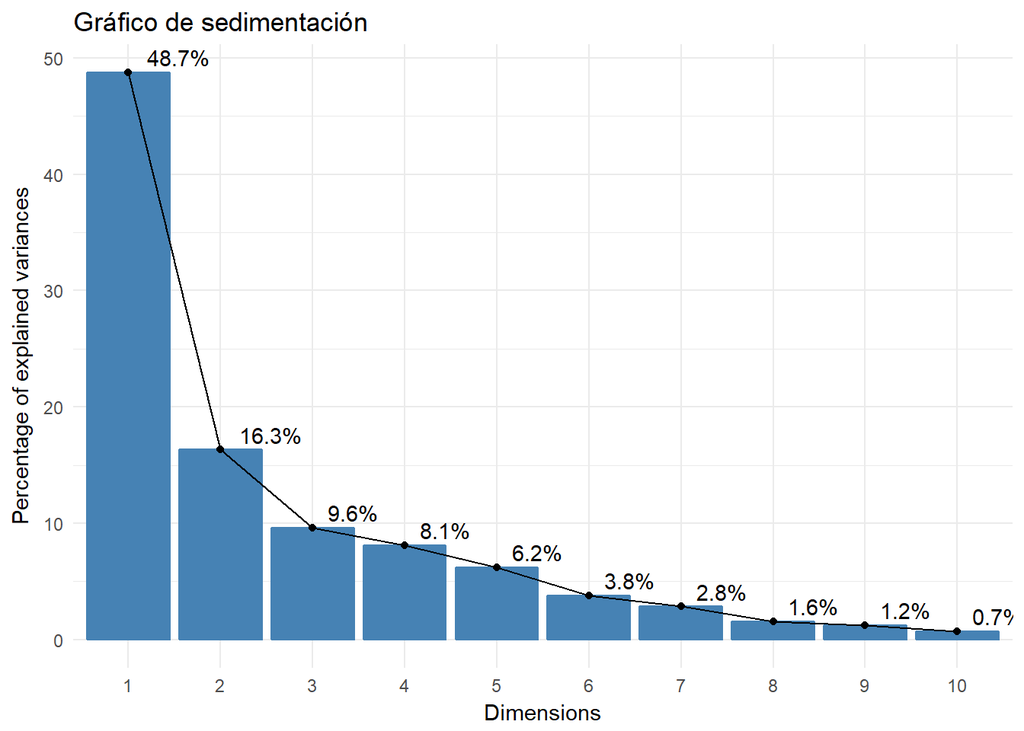

```r
fviz_eig(data.pca, addlabels=T, hjust=-0.3)+
  labs(title="Gráfico de sedimentación")+
  theme_minimal()
```

Aplicando la regla del codo sobre el gráfico anterior, por la que cada factor debe explicar al menos lo que explicaría cada variable en una situación de máxima equidad explicativa (13 variables, 7.69% cada una), podemos en principio considerar como 4 el número de factores comunes a extraer.

Veremos cuáles son las variables que más contribuyen a la explicación de los primeros 4 componentes principales, cabe señalar que los componentes principales son idenpendientes entre ellos por lo que trataremos de describir que características son las mas importantes para cada componente.

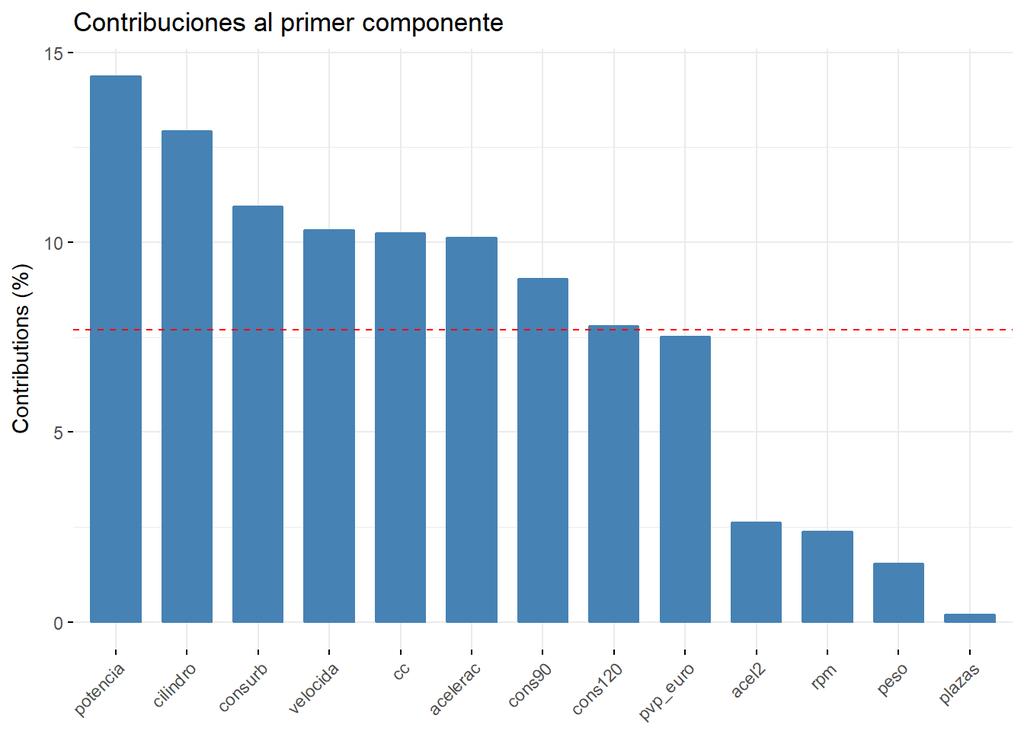

```r
fviz_contrib(data.pca, choice = "var", axes = 1) +
  labs(title="Contribuciones al primer componente")
```

Las variables principales en este componente son la potencia, cilindrada, velocidad y número de cilindros por lo que podríamos resumir este componente como la potencia del vehículo.

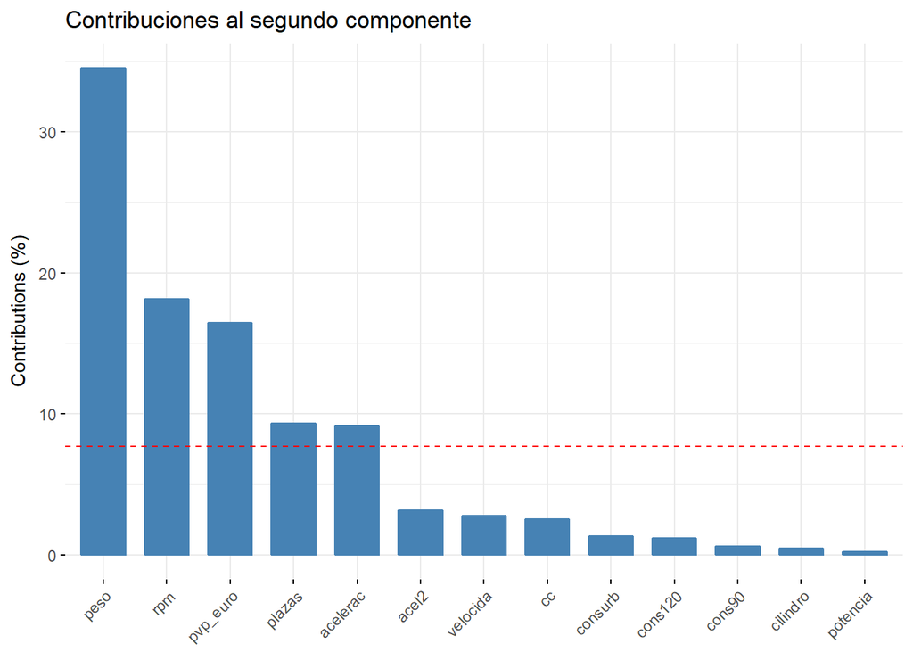

```r
fviz_contrib(data.pca, choice = "var", axes = 2) +
  labs(title="Contribuciones al segundo componente")
```

Las variable principal del segundo componente es en su mayor parte el peso del vehículo.

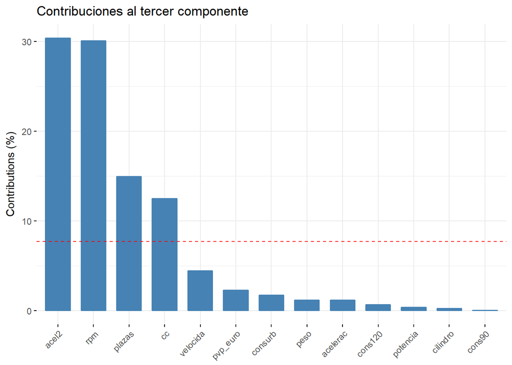

```r
fviz_contrib(data.pca, choice = "var", axes = 3) +
  labs(title="Contribuciones al tercer componente")
```

Las variables principales del tercer componente son la aceleración y las revoluciones por minuto, por lo que resumimos este componente como la acelaración del vehículo.

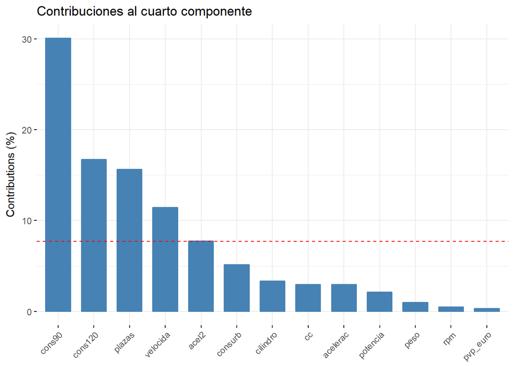

```r
fviz_contrib(data.pca, choice = "var", axes = 4) +
  labs(title="Contribuciones al cuarto componente")
```

Por último, el cuarto componente lo resumiremos como el consumo del vehículo.

Después de este análisis logramos extraer 4 características principales de los todo terreno que son:

- Potencia
- Peso
- Aceleración
- Consumo

Ahora utilizando la reducción de la dimensión que acabamos de realizar, representaremos los datos en 2 dimensiones.

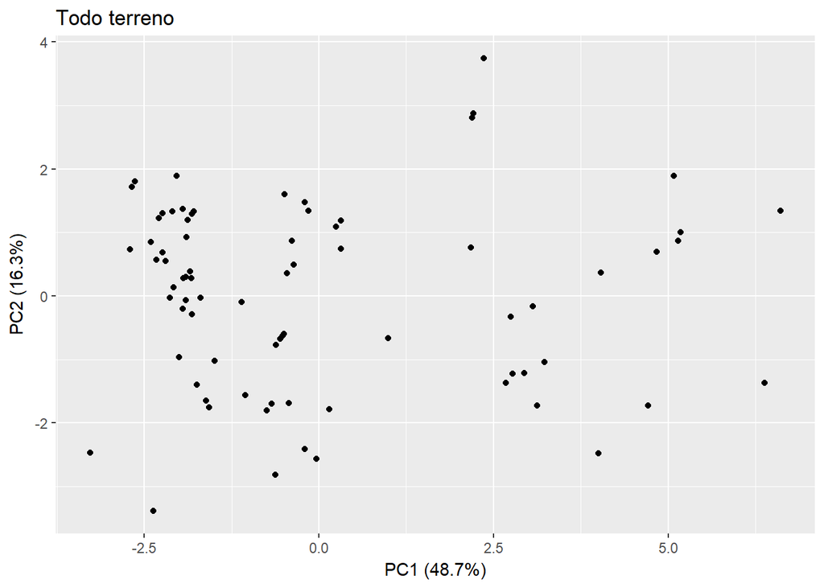

```r
ggplot(graf,aes(x=PC1,y=PC2))+geom_point()+ggtitle('Todo terreno')+
  xlab('PC1 (48.7%)')+ylab('PC2 (16.3%)')
```

Notamos que en esta representación se pueden apreciar dos o tres posibles clusters. Con estas 2 nuevas dimensiones logramos explicar el 65% de la varianza total de nuestros datos originales, pero, ¿cómo saber que tan bien estamos representando a cada una de las variables? Lo que estamos buscando es la calidad de la representación y para esto nos apoyaremos en el coseno cuadrado. Recordar que, un coseno cuadrado alto nos dice que la variable está bien representada en los componente principales. Un coseno cuadrado bajo no indica que la variable no está bien representada por los componentes principales.

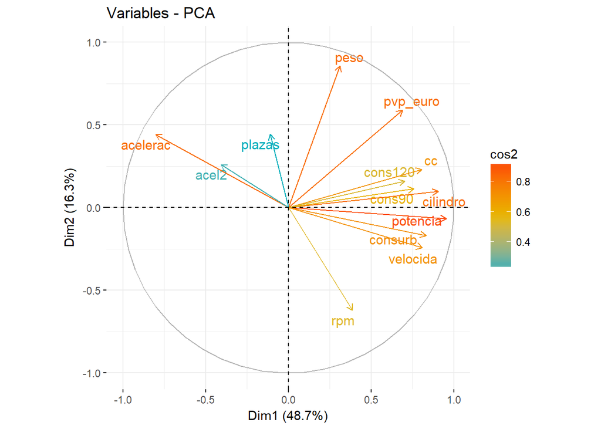

```r
fviz_pca_var(data.pca, col.var = "cos2",
             gradient.cols = c("#00AFBB", "#E7B800", "#FC4E07"),
             repel = TRUE
)
```

En general todas nuestras variables están bien representadas por las nuevas dimensiones, exceptuando las plazas y el tiempo de aceleración.

Usaremos un método de aprendizaje no supervisado (k medias) para hacer clusters, esto porque nuestro dataset no tiene categorias o grupos definidos.

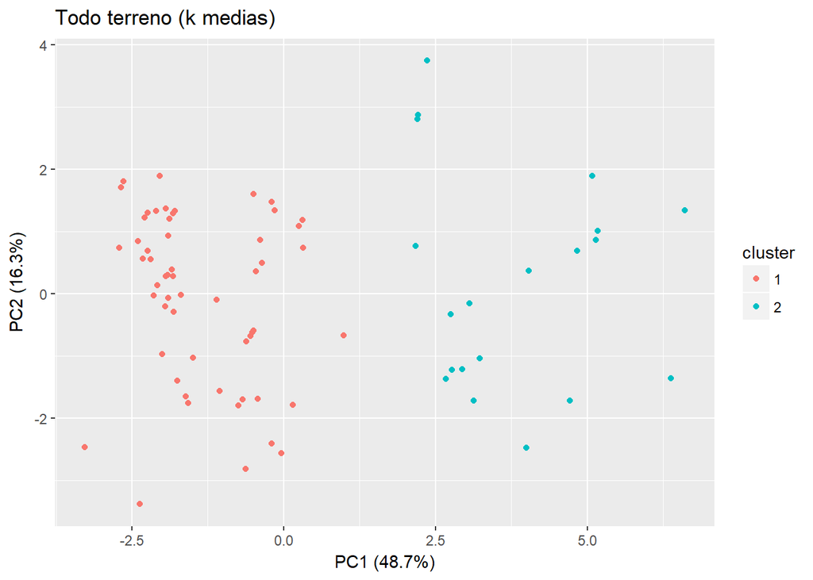

```r
ggplot(graf,aes(x=PC1,y=PC2))+geom_point(aes(col=cluster))+ggtitle('Todo terreno (k medias)')+
  xlab('PC1 (48.7%)')+ylab('PC2 (16.3%)')
```

En el gráfico se puede apreciar como se forman los dos clusters que comentábamos anteriormente.

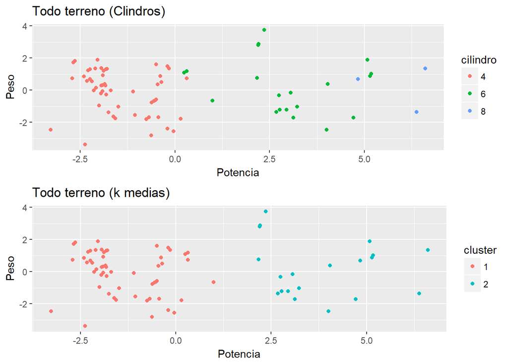

```r
grid.arrange(ggplot(graf,aes(x=PC1,y=PC2))+geom_point(aes(col=cilindro))+ggtitle('Todo terreno (Clindros)')+
  xlab('Potencia')+ylab('Peso'),
ggplot(graf,aes(x=PC1,y=PC2))+geom_point(aes(col=cluster))+ggtitle('Todo terreno (k medias)')+
  xlab('Potencia')+ylab('Peso'))
```

Este gráfico es muy interesante, ya que los clusters que creamos anteriormente coinciden casi perfectamente si hicieramos un grupo con los todo terreno de 4 cilindros y otro con los de más de 6. Esto querría decir que lo que más diferencía a los todo terreno entre sí son la cantidad de cilindros que poseen. Es interesante notar que mientras más cilindros tiene el vehículo la potencia tambien aumenta.

## Conclusión

Se logró encontrar las características intrinsecas de los datos con el método de componentes principales (potencia, peso , aceleración y consumo). Utilizando el sentido común podemos llegar a la conclusión de que el análisis fue realizado correctamente ya que estás características son evidentes de los vehículos todo terreno. Las principales limitaciones de este método se vieron reflejadas en el primer componente principal puesto que la mayoría de las variables aportaban la misma cantidad de información al componente. Esto se debe a la gran correlación que hay entre estas variables y puede ser un problema cuando el objetivo es extraer cualidades o características de la base de datos, pero si nuestro objetivo es sólo reducir la dimensión nos sería de gran utilidad ya que estaremos reduciendo la información de la mayoría de las variables en un solo componente principal. En el análisis cluster realizado pudimos encontrar la característica que más diferencía a los todo terreno entre ellos mismos, esta característica fue el número de cilindros del vehículo.

Por último, podemos concluir que el análisis de componentes principales nos sirvió para encontrar características en común entre los todo terreno y el análisis cluster nos ayudó a encontrar la característica que más los diferenecía entre sí.

## Anexo

### Preparación de los datos

Primero leemos los datos y omitimos los NA, esto es importante debido a que puede darnos problemas a la hora de realizar el PCA. También es importante revisar los principales estadísticos de cada una de las variables, esto nos ayuda a saber si debemos escalar las variables.

```r
data <-read.csv('tterreno_euro.csv')
data <- na.omit(data)
summary(data)
```

```
##      marca                         modelo      pvp_euro
##  Min.   : 2.000   Montero La. TDI 2.8 : 3   Min.   : 9882
##  1st Qu.: 7.750   Monterey 3.2i V6 24V: 2   1st Qu.:23967
##  Median : 9.000   Montero Co. TDI 2.5 : 2   Median :28547
##  Mean   : 8.671   Montero Co. TDI 2.8 : 2   Mean   :31635
##  3rd Qu.:11.000   Montero Corto 3.0 GL: 2   3rd Qu.:32473
##  Max.   :13.000   Terrano II 2.7 TD LX: 2   Max.   :69461
##                   (Other)             :63
##     cilindro           cc          potencia          rpm
##  Min.   :4.000   Min.   :1589   Min.   : 80.0   Min.   :3600
##  1st Qu.:4.000   1st Qu.:2477   1st Qu.:112.0   1st Qu.:4000
##  Median :4.000   Median :2663   Median :121.5   Median :4200
##  Mean   :4.684   Mean   :2817   Mean   :132.6   Mean   :4519
##  3rd Qu.:6.000   3rd Qu.:3059   3rd Qu.:136.0   3rd Qu.:5200
##  Max.   :8.000   Max.   :5216   Max.   :225.0   Max.   :6000
##
##       peso          plazas          cons90          cons120
##  Min.   :1200   Min.   :2.000   Min.   : 6.600   Min.   : 8.60
##  1st Qu.:1696   1st Qu.:5.000   1st Qu.: 8.300   1st Qu.:11.20
##  Median :1819   Median :5.000   Median : 9.200   Median :12.70
##  Mean   :1817   Mean   :5.421   Mean   : 9.283   Mean   :12.79
##  3rd Qu.:1986   3rd Qu.:7.000   3rd Qu.:10.450   3rd Qu.:14.20
##  Max.   :2280   Max.   :9.000   Max.   :13.700   Max.   :18.50
##
##     consurb         velocida        acelerac         acel2
##  Min.   : 8.60   Min.   :125.0   Min.   : 9.40   Min.   :1.000
##  1st Qu.:11.60   1st Qu.:145.0   1st Qu.:13.20   1st Qu.:2.000
##  Median :13.30   Median :150.0   Median :15.60   Median :2.000
##  Mean   :13.59   Mean   :155.7   Mean   :15.37   Mean   :1.961
##  3rd Qu.:15.90   3rd Qu.:168.2   3rd Qu.:18.50   3rd Qu.:2.000
##  Max.   :22.10   Max.   :196.0   Max.   :22.00   Max.   :2.000
##
```

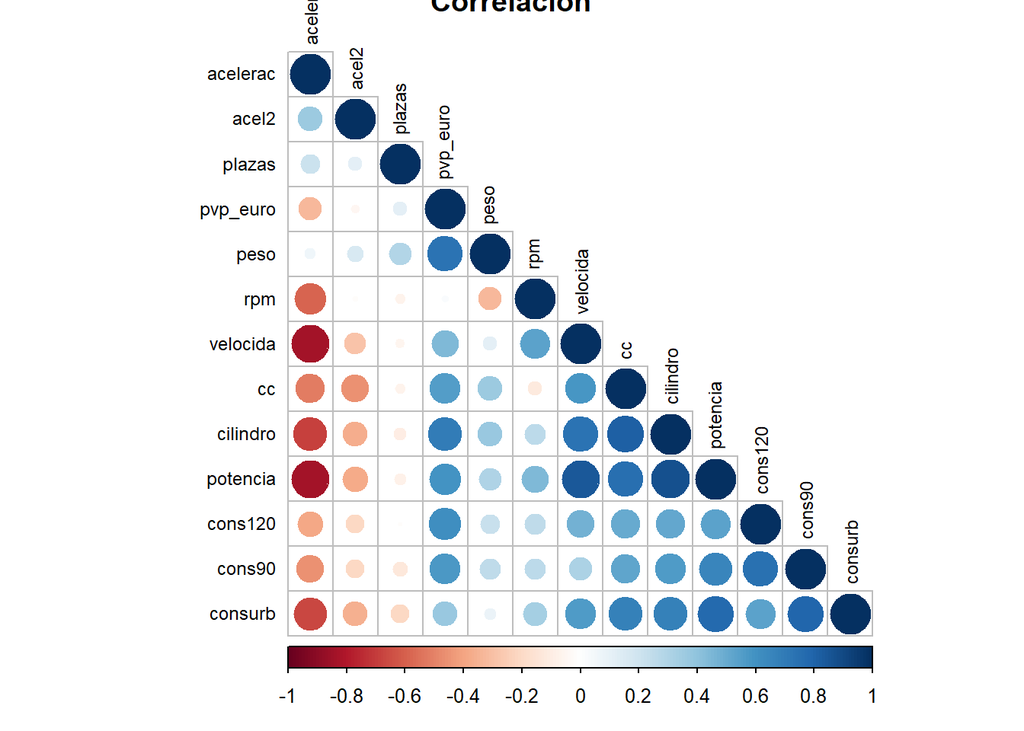

```r
corrplot(cor(data[,3:15]),
         order = "hclust", tl.col='black', tl.cex=.75,
         type = 'lower',title = 'Correlacion')
```

### Análisis de Componentes Principales

Realizamos el análisis de componentes principales.

```r
data.pca <- prcomp(data[,3:15],
                 center = TRUE,
                 scale. = TRUE)
summary(data.pca)
```

```
## Importance of components:
##                           PC1    PC2     PC3     PC4     PC5     PC6
## Standard deviation     2.5173 1.4570 1.11799 1.02722 0.89819 0.70224
## Proportion of Variance 0.4875 0.1633 0.09615 0.08117 0.06206 0.03793
## Cumulative Proportion  0.4875 0.6508 0.74691 0.82808 0.89013 0.92807
##                            PC7     PC8     PC9    PC10    PC11    PC12
## Standard deviation     0.60835 0.45109 0.39902 0.30432 0.22954 0.20448
## Proportion of Variance 0.02847 0.01565 0.01225 0.00712 0.00405 0.00322
## Cumulative Proportion  0.95654 0.97219 0.98444 0.99156 0.99561 0.99883
##                           PC13
## Standard deviation     0.12338
## Proportion of Variance 0.00117
## Cumulative Proportion  1.00000
```

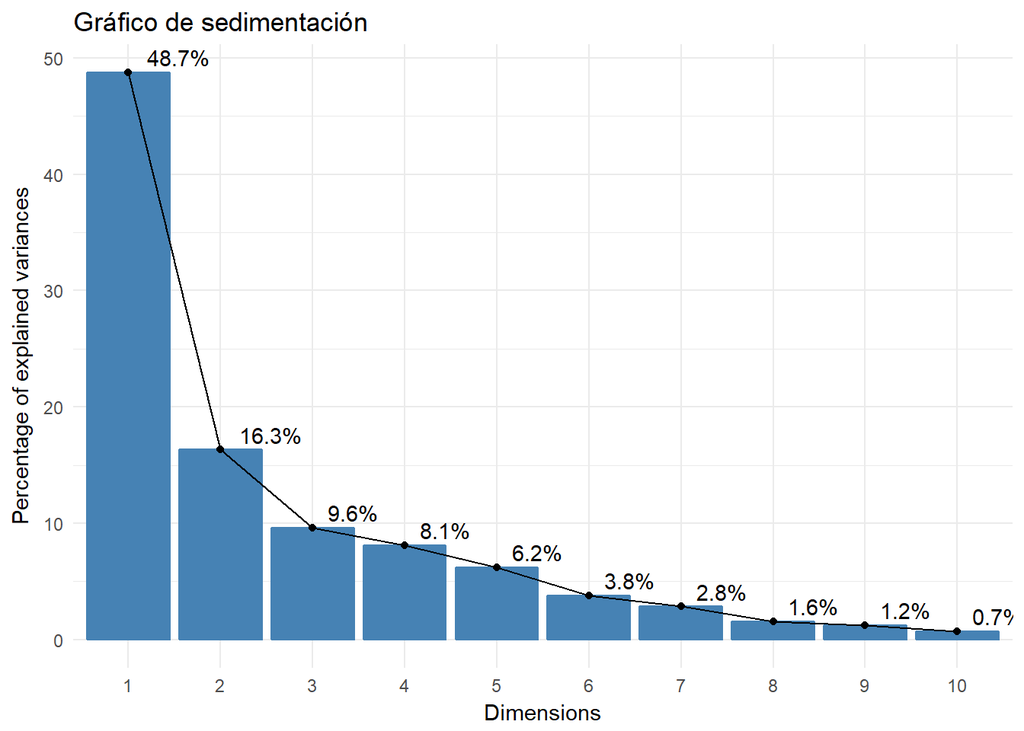

```r
fviz_eig(data.pca, addlabels=T, hjust=-0.3)+
  labs(title="Gráfico de sedimentación")+
  theme_minimal()
```

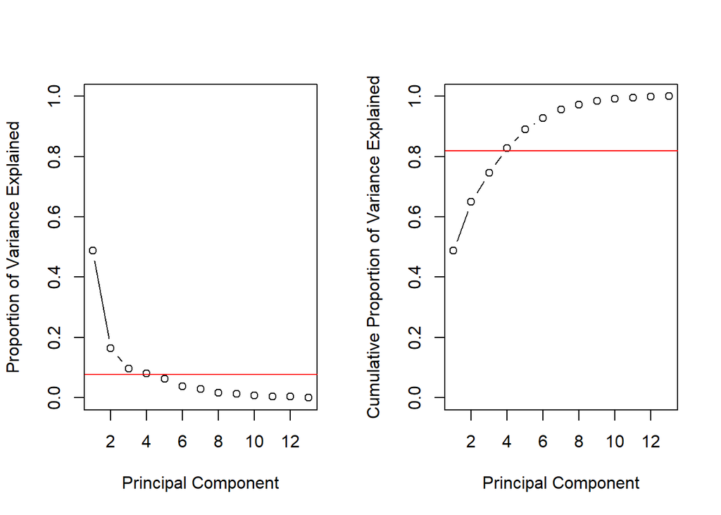

```r
pve <- data.pca$sdev**2
ve <- pve/sum(pve)
par(mfrow = c(1, 2))
# Plot variance explained for each principal component
plot(ve, xlab = "Principal Component",
     ylab = "Proportion of Variance Explained",
     ylim = c(0, 1), type = "b")
abline(h=1/13,col=2)
# Plot cumulative proportion of variance explained
plot(cumsum(ve), xlab = "Principal Component",
     ylab = "Cumulative Proportion of Variance Explained",
     ylim = c(0, 1), type = "b")
abline(h=.82,col=2)
```

Notamos que con 4 componentes principales podemos explicar el 82% de la varianza total por lo que estaríamos reduciendo de 13 dimensiones a 4 con muy poca perdida de información.

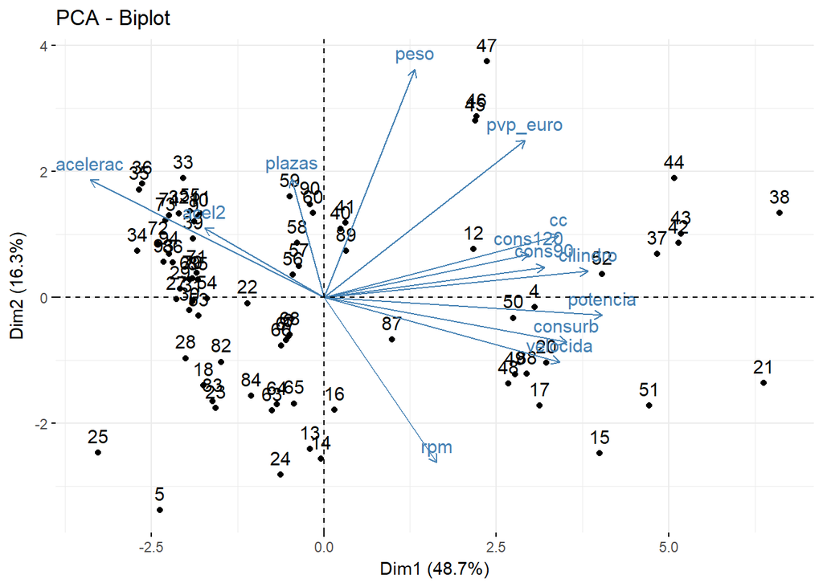

```r
fviz_pca_biplot(data.pca)
```

En el gráfico se aprecia que una gran cantidad de variables están cerca del eje x positivo, lo que quiere decir que están muy relacionadas entre ellas, esto facilita el análisis de componentes principales.

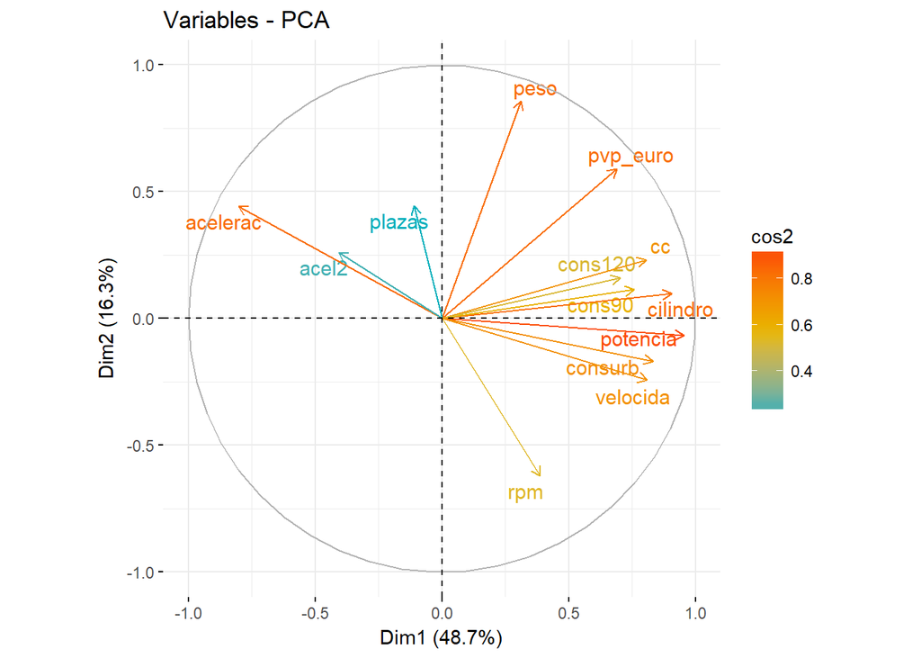

```r
fviz_pca_var(data.pca, col.var = "cos2",
             gradient.cols = c("#00AFBB", "#E7B800", "#FC4E07"),
             repel = TRUE # Avoid text overlapping
)
```

Aquí ser observa que al reducir en dos dimensiones hay dos variables que pierdan calidad de información las cuales son tiempo de aceleración y plazas.

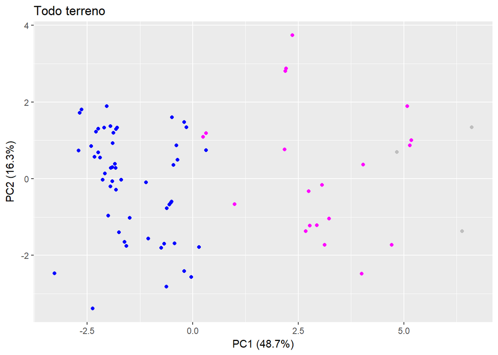

```r
graf <- as.data.frame(data.pca$x[,1:2])
ggplot(graf,aes(x=PC1,y=PC2))+geom_point(col=data$cilindro)+ggtitle('Todo terreno')+
  xlab('PC1 (48.7%)')+ylab('PC2 (16.3%)')
```

### Análisis Cluster

Debido a que los datos no tienen etiquetas o categorías utilizaremos el algoritmo k-medias para obtener clusters dentro de nuetros datos. Primero veremos cómo disminuye el error mientras aumentamos los grupos en nuestro algoritmo.

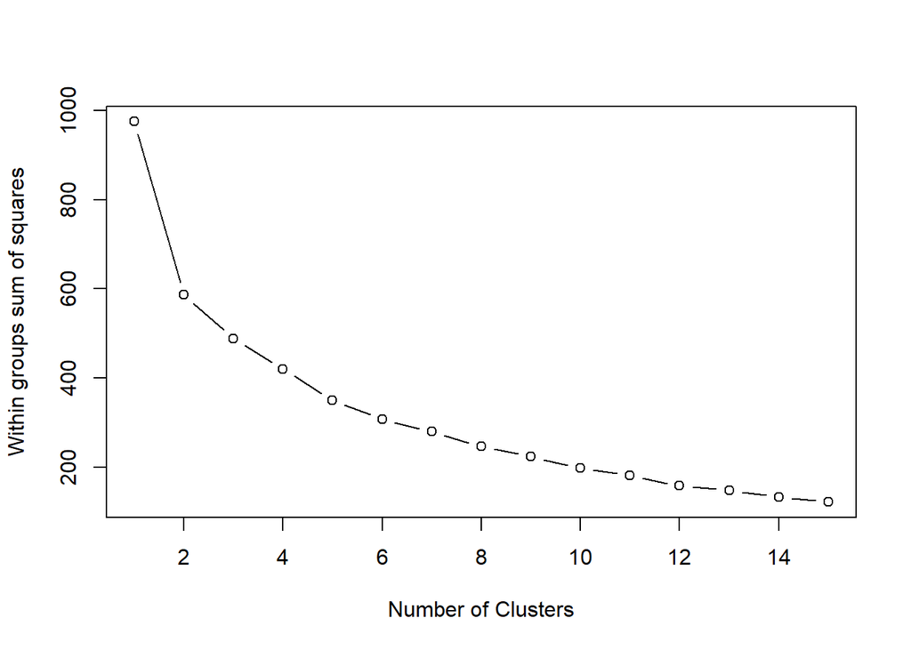

```r
wss <-0
for (i in 1:15) {
  km.out <- kmeans(scale(data[,3:15]), centers = i, nstart=20)
  wss[i] <- km.out$tot.withinss
}

plot(1:15, wss, type = "b",
     xlab = "Number of Clusters",
     ylab = "Within groups sum of squares")
```

Según la regla del codo deberíamos realizar 2 o 3 clusters, ya que aumentando clusters el error disminuye poco y aumenta el overfitting en el análisis.

K-medias con k=2

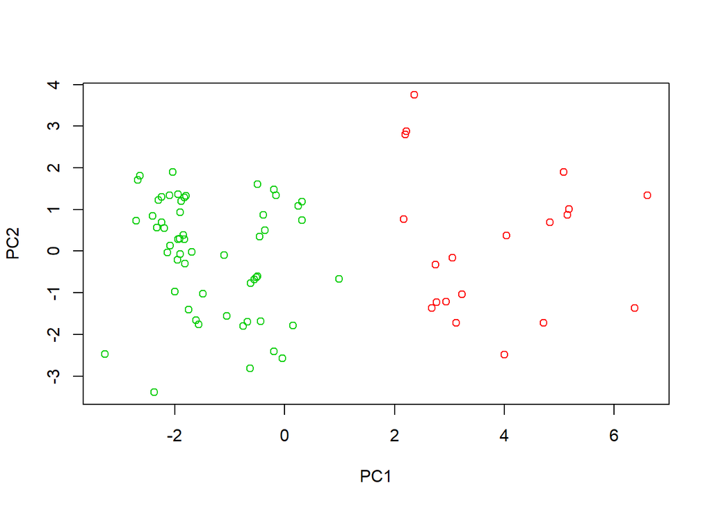

```r
kmedias <- kmeans(scale(data[,3:15]),2,nstart = 20)
plot(data.pca$x[, c(1, 2)],col=kmedias$cluster+1,
     xlab = "PC1", ylab = "PC2")
```

K-medias con k=3

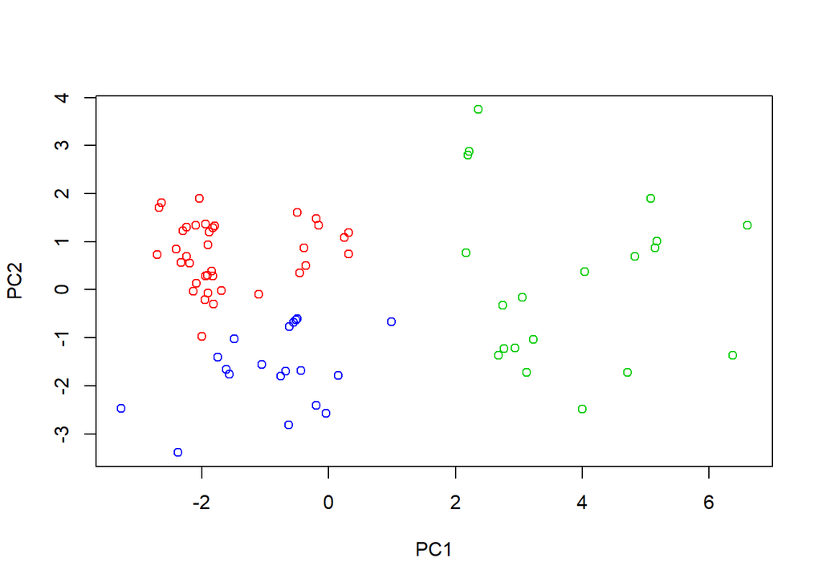

```r
kmedias <- kmeans(scale(data[,3:15]),3,nstart = 20)
plot(data.pca$x[, c(1, 2)],col=kmedias$cluster+1,
     xlab = "PC1", ylab = "PC2")
```

Despues de ver los dos gráficos decido quedarme con k=2 ya que los clusters se forman de manera mas homogenea.

El siguiente código lo utilicé para realizar un gráfico en 3D con plotly, pero no funciona en RMarkdown.

```r
# prueba <-as.data.frame(data.pca$x)
# prueba$clust <- as.factor(kmedias$cluster)
#
# plot_ly(data =prueba ,x = ~PC1,
#         y = ~PC2, z = ~PC3,color = ~clust,type = "scatter3d",showlegend = FALSE)
```

# Referencias

Gurrea, Manuel. 2000. “Análisis de Componentes Principales.” Proyecto e-Math Financiado por la Secretaría de Estado de Educación y Universidades (MECD). https://www.uoc.edu/in3/emath/docs/Componentes_principales.pdf.

Kassambara, Alboukadel. 2017. “PCA - Principal Component Analysis Essentials.” http://www.sthda.com/english/articles/31-principal-component-methods-in-r-practical-guide/112-pca-principal-component-analysis-essentials/.

Llopis, Jaume. 2013. “Análisis Factorial.” https://estadisticaorquestainstrumento.wordpress.com/2013/01/02/tema-18-analisis-factorial/.

Martins, Thiago. 2013. “Computing and Visualizing PCA in R.” https://www.r-bloggers.com/computing-and-visualizing-pca-in-r/.

Roark, Hank. 2016. “Unsupervised Learning.” https://www.datacamp.com/courses/unsupervised-learning-in-r.